# R MINI PROJECT ASSIGNMENT

MUSIIME CAROLINE JACKLINE

9/14/2021

## MSB7102 Mini-project, Semester I, 2021

**1.Import the data described above into R, provide descriptive summaries of the subject data (using appropriate graphics and statistical summary measures) given in the diabimmune_16s_t1d_metadata.csv file. In addition, use appropriate test(s) to check for association/independency between disease status and other variables (delivery mode, gender and age).**

```r
data <- read.csv("taxa_table_.csv");
#View(data)
```

```r
summary(data)
```

```
##  ï..Sample_ID        Subject_ID        Case_Control          Gender
##  Length:777         Length:777         Length:777         Length:777
##  Class :character   Class :character   Class :character   Class :character
##  Mode  :character   Mode  :character   Mode  :character   Mode  :character
##
##
##
##  Delivery_Route     Age_at_Collection
##  Length:777         Min.   :   6.0
##  Class :character   1st Qu.: 229.0
##  Mode  :character   Median : 452.0
##                     Mean   : 482.9
##                     3rd Qu.: 702.0
##                     Max.   :1233.0
```

```r
head(data)
```

```
##   ï..Sample_ID Subject_ID Case_Control Gender Delivery_Route Age_at_Collection
## 1       G36449    E001463      control   male        vaginal                62
## 2       G36034    E001463      control   male        vaginal                82
## 3       G36993    E001463      control   male        vaginal               124
## 4       G35523    E001463      control   male        vaginal               153
## 5       G36450    E001463      control   male        vaginal               187
## 6       G36028    E001463      control   male        vaginal               213
```

```r
dim(data)
```

```
## [1] 777   6
```

```r
class(data)
```

```
## [1] "data.frame"
```

**Find the number of cases and controls, males and females and the delivery routes.**

```r
table(data$Case_Control)
```

```
##
##    case control
##     260     517
```

```r
table(data$Gender)
```

```
##
## female   male
##    412    365
```

```r
table(data$Delivery_Route)
```

```
##
## cesarian  vaginal
##       66      711
```

**Plot bargraphs showing the different associations.** **Load the ggplot2 package.**

```r
library(ggplot2)
```

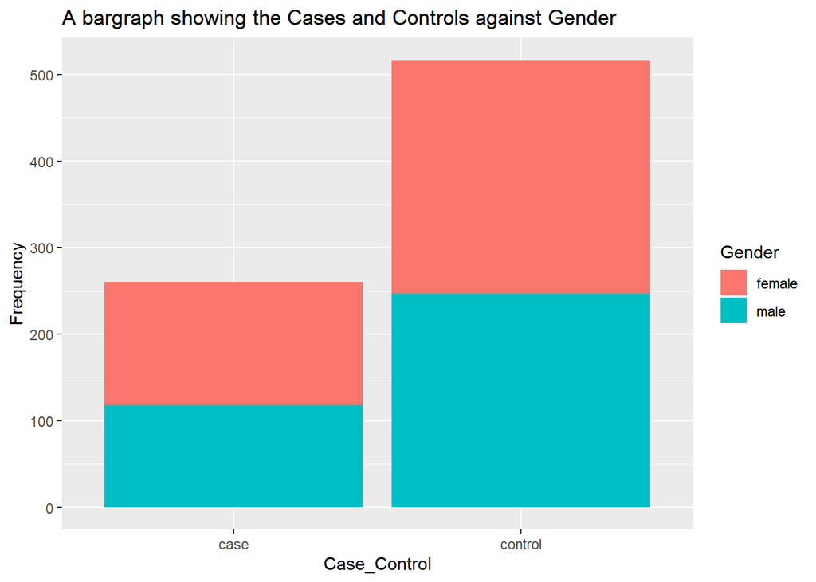

```r
qplot(data$Case_Control, fill = data$Gender) + geom_bar() + labs(title = "A bargraph showing the Cases and Controls against Gender", x = "Case_Control", y= "Frequency", fill = "Gender")
```

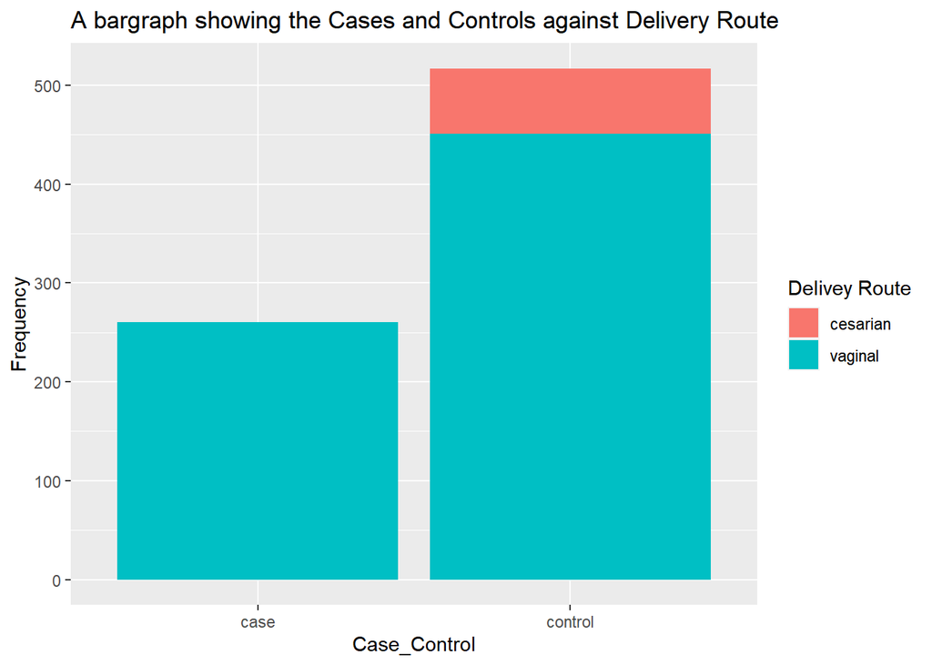

```r
qplot(data$Case_Control, fill = data$Delivery_Route) + geom_bar()+ labs(title = "A bargraph showing the Cases and Controls against Delivery Route", x = "Case_Control", y= "Frequency", fill = "Delivey Route")
```

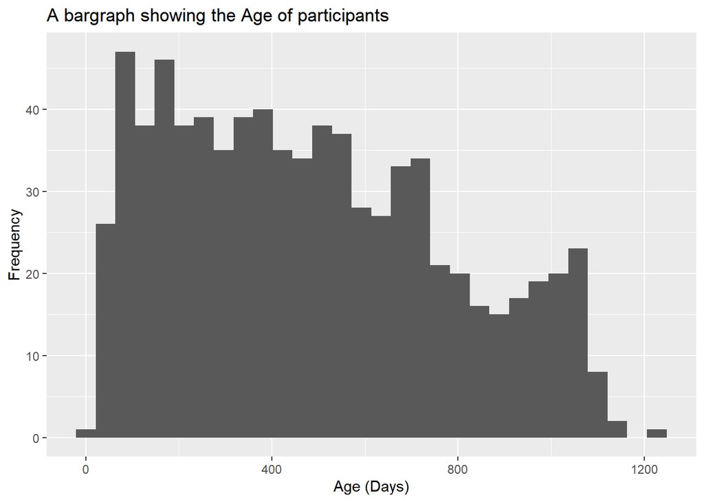

```r
qplot(data$Age_at_Collection) + geom_bar() + labs(title = "A bargraph showing the Age of participants", x = "Age (Days)", y= "Frequency")
```

**Check for association/independency between disease status and age, gender and delivery mode.**

**Generate a contingency table and perform a Chi-square statistics.**

```r
tbAge <- table(data$Case_Control,data$Age_at_Collection)
chisq.test(tbAge)
```

```
##
##  Pearson's Chi-squared test
##
## data:  tbAge
## X-squared = 532.07, df = 542, p-value = 0.6115
```

**From the statistical analysis, the P value is 0.6115, which is greater than 0.05, therefore we accept the null hypothesis indicating that there is no association between the disease state and the ages of the participants at collection.**

```r
tbGender <- table(data$Case_Control, data$Gender)
chisq.test(tbGender)
```

```
##
##  Pearson's Chi-squared test with Yates' continuity correction
##
## data:  tbGender
## X-squared = 0.30687, df = 1, p-value = 0.5796
```

**From the statistical analysis, the P value is 0.5796, which is greater than 0.05, therefore we accept the null hypothesis indicating that there is no association between the disease state and the gender.**

```r
tbDelivery_Route <- table(data$Case_Control, data$Delivery_Route)
chisq.test(tbDelivery_Route)
```

```
##
##  Pearson's Chi-squared test with Yates' continuity correction
##
## data:  tbDelivery_Route
## X-squared = 34.649, df = 1, p-value = 3.949e-09
```

**From the statistical analysis, the P value is 3.949e-09, which is less than 0.05, therefore we accept the alternate hypothesis indicating that there is a strong association between the disease state and the delivery route.**

**2. Using phyloseq, create a phyloseq object. This will comprise the OTU abundance, taxonomy (provided in the .txt file) and sample data (provided in the .csv file).**

**Import the OTU table.**

```r
otuTable <- read.table("otu_table")  #Importing the OTU table
head(otuTable, n=1)
```

[output not shown]

[output cut: 101 more lines]

[output not shown]

**Import the taxonomy table.**

```r
taxaTable <- read.table("taxa_table") #Importing the Taxa table
head(taxaTable, n=1)
```

```
##               Domain.            Phylum.                  Class.
## 4333897; k__Bacteria; p__Proteobacteria; c__Gammaproteobacteria;
##                         Order.                Family. Genus. Species
## 4333897; o__Enterobacteriales; f__Enterobacteriaceae;   g__;     s__
```

**Check the dimension and class of each table.**

```r
dim(otuTable)
```

```
## [1] 2240  777
```

```r
dim(taxaTable)
```

```
## [1] 2240    7
```

```r
class(otuTable)
```

```
## [1] "data.frame"
```

```r
class(taxaTable)
```

```
## [1] "data.frame"
```

**Convert the tables from dataframe to matrix. This is because, phyloseq works better with a matrix.**

```r
#Converting the Taxa and OTU Table into a Matrix
mtaxaTable <- as.matrix(taxaTable)
motuTable <- as.matrix(otuTable)
```

**Check the class of the matrices created.**

```r
class(motuTable)
```

```
## [1] "matrix" "array"
```

```r
class(mtaxaTable)
```

```
## [1] "matrix" "array"
```

**Data Cleansing.**

This is done to have consistent data across all the matrices. It involves making sure that the OTU/taxa row names match. Currently they don’t as taxa have a trailing “;”

#rownames(mtaxaTable)[rownames(mtaxaTable) == “4333897;”] = “4333897”

```r
head(mtaxaTable, n=1)
```

```
##          Domain.        Phylum.              Class.
## 4333897; "k__Bacteria;" "p__Proteobacteria;" "c__Gammaproteobacteria;"
##          Order.                  Family.                  Genus. Species
## 4333897; "o__Enterobacteriales;" "f__Enterobacteriaceae;" "g__;" "s__"
```

```r
Rnames <- rownames(mtaxaTable)  #Extract rownames from the matrix
NRnames <- gsub(x = Rnames, pattern = ";", replacement = "")  #Remove the ; from the extracted rownames
#NRnames
rownames(mtaxaTable) <- NRnames  #Set the new rownames
head(mtaxaTable, n=1) #Check to confirm that changes have been made
```

```
##         Domain.        Phylum.              Class.
## 4333897 "k__Bacteria;" "p__Proteobacteria;" "c__Gammaproteobacteria;"
##         Order.                  Family.                  Genus. Species
## 4333897 "o__Enterobacteriales;" "f__Enterobacteriaceae;" "g__;" "s__"
```

**Load the phyloseq package.**

```r
library(phyloseq)
```

**Create a phyloseq object**

```r
#Tell phyloseq to load them into a phyloseq object
OTU = otu_table(motuTable, taxa_are_rows = TRUE)
TAX = tax_table(mtaxaTable)

#OTU
#TAX

#Generating the phyloseq object and view it
physeq = phyloseq(OTU, TAX)
physeq
```

```
## phyloseq-class experiment-level object
## otu_table()   OTU Table:         [ 2240 taxa and 777 samples ]
## tax_table()   Taxonomy Table:    [ 2240 taxa by 7 taxonomic ranks ]
```

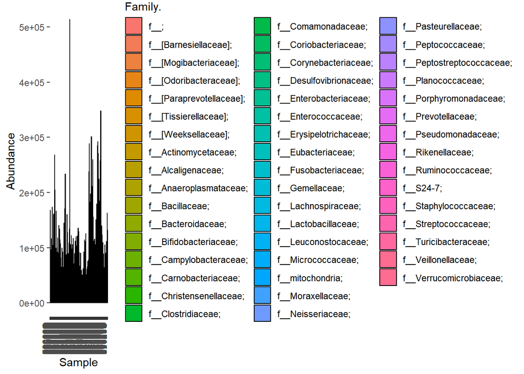

```r
#Plotting the phyloseq
plot_bar(physeq, fill = "Family.")
```

**3. Generate Alpha diversity plots and ordination plots. Examine any observed patterns by delivery mode, gender and disease status.**

**Generate a default plot from the plot_richness function.**

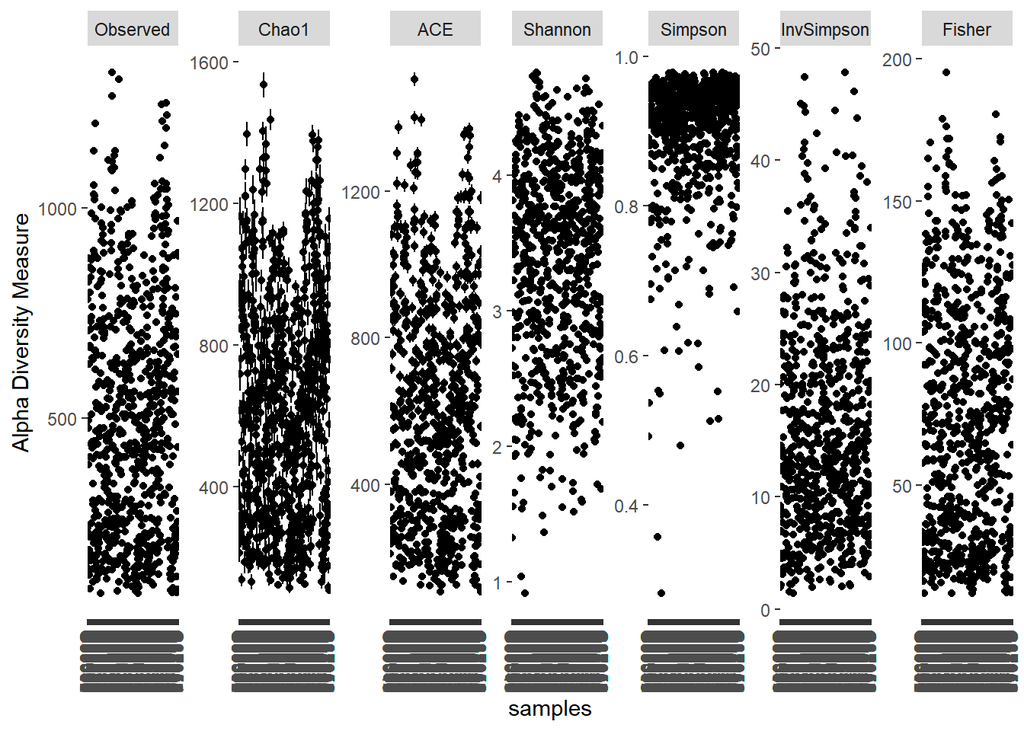

```r
plot_richness(physeq)  #Default plot produced by the plot_richness function
```

**Merge the sample data into the phyloseq object to observe patterns across variables.**

```r
library(tibble)
s_data <- column_to_rownames(data, var="ï..Sample_ID")
s_data <- sample_data(s_data)
#s_data
mergedPhyseq <- merge_phyloseq(physeq, s_data)
mergedPhyseq
```

```
## phyloseq-class experiment-level object
## otu_table()   OTU Table:         [ 2240 taxa and 777 samples ]
## sample_data() Sample Data:       [ 777 samples by 5 sample variables ]
## tax_table()   Taxonomy Table:    [ 2240 taxa by 7 taxonomic ranks ]
```

**Alpha diversity comparison between the Delivery route in cases and controls.**

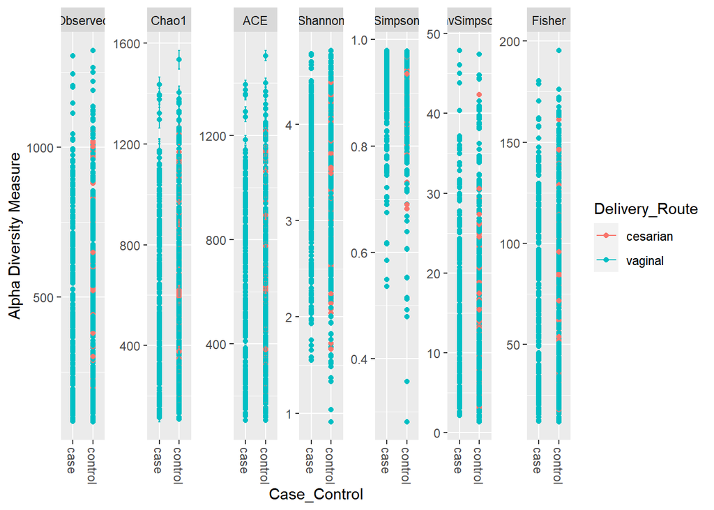

```r
plot_richness(mergedPhyseq, x ="Case_Control", color="Delivery_Route")
```

**Alpha diversity comparison between the Gender in Cases and Controls.**

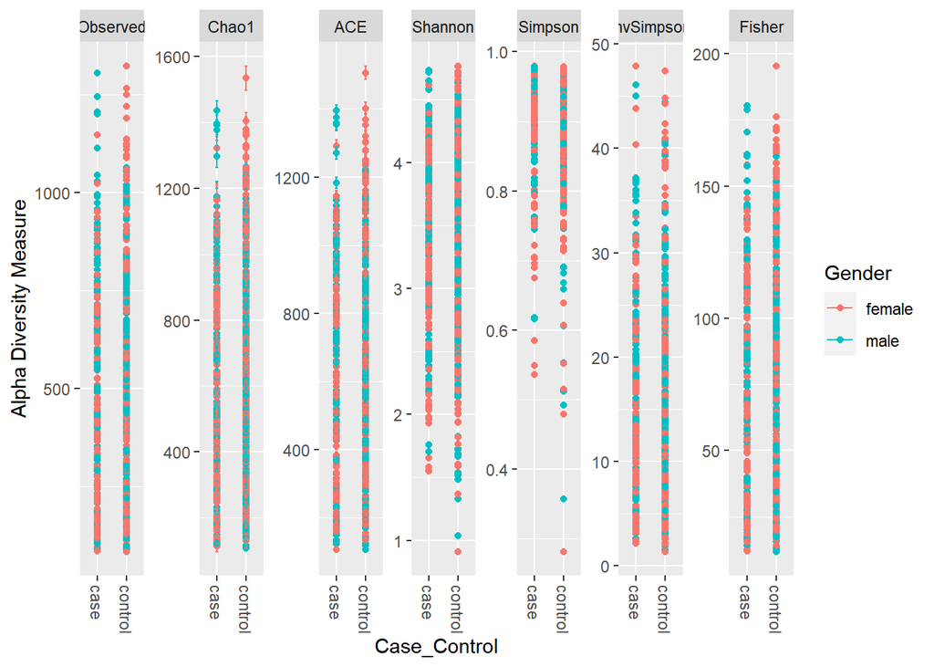

```r
plot_richness(mergedPhyseq, x ="Case_Control", color="Gender")
```

**Alpha diversity comparison between the Age in Cases and Controls.**

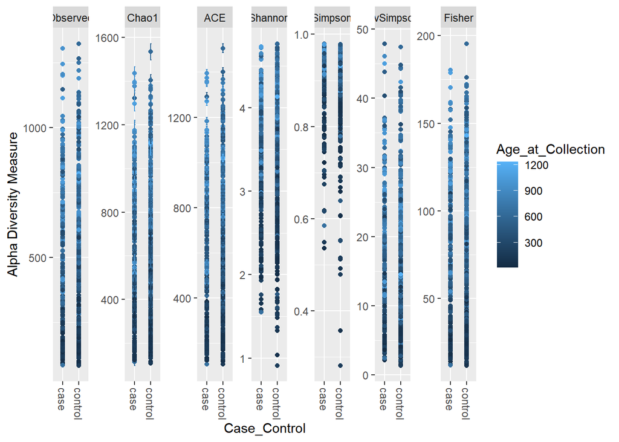

```r
plot_richness(mergedPhyseq, x ="Case_Control", color="Age_at_Collection")
```

**4. Perform differential abundance using DEseq2.**

**Load the DESeq2 package.**

```r
library("DESeq2")
```

**Convert the phyloseq object to deseq.**

```r
cacos = phyloseq_to_deseq2(mergedPhyseq, ~ Case_Control)
```

**Calculate geometric mean to estimate size factor.**

```r
gm_mean = function(x, na.rm=TRUE){
  exp(sum(log(x[x > 0]), na.rm=na.rm) / length(x))
}
geoMeans = apply(counts(cacos), 1, gm_mean)
cacos = estimateSizeFactors(cacos, geoMeans = geoMeans)
cacos = DESeq(cacos, fitType="local")
```

```
## -- replacing outliers and refitting for 1151 genes
## -- DESeq argument 'minReplicatesForReplace' = 7
## -- original counts are preserved in counts(dds)
```

**Perform the test using the DESeq function.**

```r
cacos = DESeq(cacos, test="Wald", fitType="parametric")
```

```
## found already estimated dispersions, replacing these
```

```
## -- replacing outliers and refitting for 1151 genes
## -- DESeq argument 'minReplicatesForReplace' = 7
## -- original counts are preserved in counts(dds)
```

**Investigate the test result table.**

```r
res = results(cacos, cooksCutoff = FALSE)
alpha = 0.01
sigtab = res[which(res$padj < alpha), ]
sigtab = cbind(as(sigtab, "data.frame"), as(tax_table(mergedPhyseq)[rownames(sigtab), ], "matrix"))
head(sigtab)
```

```
##            baseMean log2FoldChange     lfcSE      stat       pvalue
## 134726     5.650900       2.131343 0.5677746  3.753854 1.741366e-04
## 193672    91.723631       1.574411 0.2339004  6.731115 1.683680e-11
## 4439360 1081.732052       1.293404 0.2630281  4.917360 8.771932e-07
## 306299     7.927932       1.012606 0.2725292  3.715586 2.027331e-04
## 1142029   25.917987      -1.281229 0.2384803 -5.372474 7.766380e-08
## 4372612   14.952956       1.153463 0.2794945  4.126959 3.675921e-05
##                 padj      Domain.            Phylum.             Class.
## 134726  1.796095e-03 k__Bacteria;     p__Firmicutes;        c__Bacilli;
## 193672  1.215617e-09 k__Bacteria;     p__Firmicutes;     c__Clostridia;
## 4439360 2.083334e-05 k__Bacteria;  p__Bacteroidetes;    c__Bacteroidia;
## 306299  2.032962e-03 k__Bacteria;     p__Firmicutes;     c__Clostridia;
## 1142029 2.761921e-06 k__Bacteria; p__Actinobacteria; c__Actinobacteria;
## 4372612 4.988750e-04 k__Bacteria;  p__Bacteroidetes;    c__Bacteroidia;
##                        Order.                Family.              Genus.
## 134726    o__Lactobacillales;   f__Lactobacillaceae;   g__Lactobacillus;
## 193672      o__Clostridiales;     f__Clostridiaceae;                g__;
## 4439360     o__Bacteroidales;     f__Bacteroidaceae;     g__Bacteroides;
## 306299      o__Clostridiales;    f__Lachnospiraceae;                g__;
## 1142029 o__Bifidobacteriales; f__Bifidobacteriaceae; g__Bifidobacterium;
## 4372612     o__Bacteroidales;     f__Bacteroidaceae;     g__Bacteroides;
##         Species
## 134726      s__
## 193672      s__
## 4439360     s__
## 306299      s__
## 1142029     s__
## 4372612     s__
```

```r
dim(sigtab)
```

```
## [1] 279  13
```

**Visualize the result.**

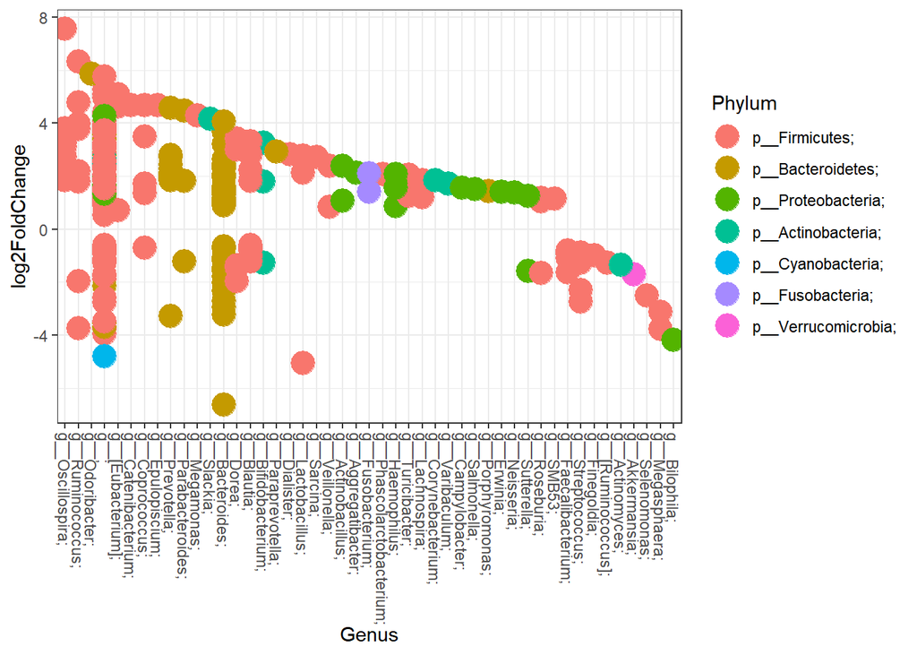

```r
library("ggplot2")
theme_set(theme_bw())
scale_fill_discrete <- function(palname = "Set1", ...) {
  scale_fill_brewer(palette = palname, ...)
}
# Phylum order
x = tapply(sigtab$log2FoldChange, sigtab$Phylum, function(x) max(x))
x = sort(x, TRUE)
sigtab$Phylum = factor(as.character(sigtab$Phylum), levels=names(x))
# Genus order
x = tapply(sigtab$log2FoldChange, sigtab$Genus, function(x) max(x))
x = sort(x, TRUE)
sigtab$Genus = factor(as.character(sigtab$Genus), levels=names(x))
ggplot(sigtab, aes(x=Genus, y=log2FoldChange, color=Phylum)) + geom_point(size=6) +
  theme(axis.text.x = element_text(angle = -90, hjust = 0, vjust=0.5))
```